# Catch and Release

2020-03-20

Today we’re going to think through how to estimate the number of fish in a lake. This kind of problem is faced regularly by [ecologists](https://en.wikipedia.org/wiki/Mark_and_recapture) trying to estimate population sizes. It will also give us a great tour of some cool STAN fundamentals. Lets get started.

```r
library(tidyverse)
library(rstan)
```

Our approach will be to tag a few fish, wait a while, then catch some more. The proportion of new fish with original tags will give us the information we need to make estimates about the larger population.

To make it concrete, lets simulate some data. Suppose we catch, tag, and release 68 fish. Then, after a month, we go fishing again. This time we landed 219 rainbow trout, 16 of which were marked.

```r
# Data collection
dlist <- list(
  tagged = 68,
  captured = 219,
  returned = 16)
dlist
```

```
$tagged
[1] 68

$captured
[1] 219

$returned
[1] 16
```

To buid our intuition for this problem, we can think of the ratio of marked fish in our recapture session as representative of the larger population.

$$\begin{align}
\frac{returned}{captured} &= \frac{tagged}{N} \\
N &= \frac{tagged}{\frac{returned}{captured}}
\end{align}$$

Popping this equation in to R and getting our estimate is easy.

```r
map <- with(dlist, tagged / (returned / captured))
map
```

```
[1] 930.75
```

The question becomes more interesting when you consider the amount of uncertainty around that estimate. This is important to quantify because it may influence us to gather more data by going out and tagging catching, and releasing again.

To get that more holistic answer to this question, lets start model building. We’ll consider each caught fish as a bernoulli trial where a success is whether or not it was tagged. We can aggregate up bernoulli trials into a binomial model. This is shown in the equation below. Our free parameter is the number of total fish in the lake, $N$.

$$\begin{align}
returned &\sim Binomial(captured, \frac{tagged}{N}) \\
\end{align}$$

Lets encode this model directly in stan. Note that we are using a flat prior which will make the posterior representative of the MAP estimate above. In reality, we would probably have decent priors based on the size of the lake, previous studies, or information about other lakes.

```stan
data {
  int<lower=0> tagged;
  int<lower=0> captured;
  int<lower=0, upper=min(tagged, captured)> returned;
}
parameters {
  real<lower=(captured + tagged - returned)> N;
}
model {
  returned ~ binomial(captured, tagged / N);
}
```

```stan
data {
  int<lower=0> tagged;
  int<lower=0> captured;
  int<lower=0, upper=min(tagged, captured)> returned;
}
parameters {
  real N;
}
model {
  returned ~ binomial(captured, tagged / N);
}
```

Now that we’ve spelled it all out, let’s take the model to the data. We pop our observations in to stan and let it search around for N.

```r
fit <- sampling(lincolnpeterson, data = dlist, refresh = 0,
                chains = 4, cores = 4, iter = 4000)
print(fit, probs = c(.95, .05))
```

```
Inference for Stan model: stan-1123f3afe312a.
4 chains, each with iter=4000; warmup=2000; thin=1;
post-warmup draws per chain=2000, total post-warmup draws=8000.

        mean se_mean     sd     95%     5% n_eff Rhat
N    1055.37    5.19 284.76 1576.97 687.16  3011    1
lp__  -51.23    0.01   0.73  -50.72 -52.69  3466    1

Samples were drawn using NUTS(diag_e) at Sun Mar 22 20:29:24 2020.
For each parameter, n_eff is a crude measure of effective sample size,
and Rhat is the potential scale reduction factor on split chains (at
convergence, Rhat=1).
```

Lets zoom in to the N parameter and visualize it. I’m always playing with different ways to plot posterior distributions and this is my latest favorite. It’s interesting to note the difference between mode and mean of the distribution. Our analysis has allocated significant belief to the right of the distribution. This goes to show that the MAP values returned by frequentist analyses aren’t always the best to go with.

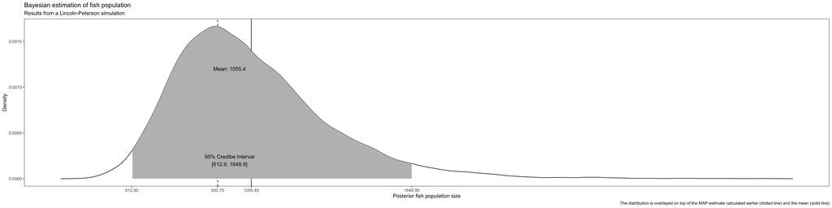

```r
posterior <- rstan::extract(fit)
dens <- density(posterior$N)

df_dens <- tibble(
  x = dens$x,
  y = dens$y)

ci <- round(as_vector(HDInterval::hdi(posterior$N)), 1)
m <- round(mean(posterior$N), 1)

df_dens %>%
  ggplot(aes(x, y)) +
    geom_vline(xintercept = map, linetype=2) +
    geom_vline(xintercept = m) +
    geom_line() +
    geom_ribbon(data = filter(df_dens, x > ci[[1]] & x < ci[[2]]),
                aes(ymin = 0, ymax = y),
                fill = "grey", color = "transparent") +
    annotate("text", x = 975, y = .0002, label = glue::glue("95% Credibe Interval\n[{ci[1]}, {ci[2]}]")) +
    annotate("text", x = 975, y = .0012, label = glue::glue("Mean: {m}")) +
    ggtitle("Bayesian estimation of fish population", "Results from a Lincoln-Peterson simulation") +
    labs(caption = "The distribution is overlayed on top of the MAP estimate calculated earlier (dotted line) and the mean (solid line)") +
    scale_y_continuous("Density") +
    scale_x_continuous("Posterior fish population size", breaks = as.numeric(c(ci, m, map))) +
    theme(panel.background = element_rect(color = "black", fill = "transparent"),
          panel.grid = element_blank())
```

And there we have it. With this distribution we can make future informed decisions based on the health of the lake. We can also gather more data to get more certainty about our measurment. We made a major assumption with this model - there were no deaths or births in the larger population. There are some really cool new [higherarchical flavors of mark and recapture models](http://www.stats.otago.ac.nz/webdata/resources/matthew_schofield/PhD_research/PhDThesisrevised.pdf) that I may revisit here if there is interest.